# ■ Analyzing and Forecasting Unemployment Trends in India ■

### Contributors :-

#### 1). Vansh Jasrotia

#### 2). Vinay Saraswat

#### 3). Rahul Khan

#### 4). Arman Khan

#### 5). Bhawna Sharma

#### 6). Maanav Aditya Sinha

```python
import numpy as np
import pandas as pd
import matplotlib.pyplot as plt
import seaborn as sns
```

```python
df = pd.read_csv(r"C:\Users\91817\Downloads\Unemployment in India.csv")
df
```

|  | Region | Date | Frequency | Estimated Unemployment Rate (%) | Estimated Employed | Estimated Labour Participation Rate (%) | Area |
| --- | --- | --- | --- | --- | --- | --- | --- |
| 0 | Andhra Pradesh | 31-05-2019 | Monthly | 3.65 | 11999139.0 | 43.24 | Rural |
| 1 | Andhra Pradesh | 30-06-2019 | Monthly | 3.05 | 11755881.0 | 42.05 | Rural |
| 2 | Andhra Pradesh | 31-07-2019 | Monthly | 3.75 | 12086707.0 | 43.50 | Rural |
| 3 | Andhra Pradesh | 31-08-2019 | Monthly | 3.32 | 12285693.0 | 43.97 | Rural |
| 4 | Andhra Pradesh | 30-09-2019 | Monthly | 5.17 | 12256762.0 | 44.68 | Rural |
| ... | ... | ... | ... | ... | ... | ... | ... |
| 749 | West Bengal | 29-02-2020 | Monthly | 7.55 | 10871168.0 | 44.09 | Urban |
| 750 | West Bengal | 31-03-2020 | Monthly | 6.67 | 10806105.0 | 43.34 | Urban |
| 751 | West Bengal | 30-04-2020 | Monthly | 15.63 | 9299466.0 | 41.20 | Urban |
| 752 | West Bengal | 31-05-2020 | Monthly | 15.22 | 9240903.0 | 40.67 | Urban |
| 753 | West Bengal | 30-06-2020 | Monthly | 9.86 | 9088931.0 | 37.57 | Urban |

754 rows × 7 columns

### ◎ Describing the Dataset :

### We can see that there are a total of 7 features in our dataset :-

#### 1). Region:

- The name of the Indian state or union territory for which the data is recorded.

#### 2). Date:

- The specific date (end of the month) when the data was collected.

#### 3). Frequency:

- The frequency of data collection — in this dataset, it is consistently "Monthly".

#### 4). Estimated Unemployment Rate (%):

- The estimated percentage of the labor force that is unemployed and actively seeking work.

#### 5). Estimated Employed:

- The estimated number of people who are currently employed in the given region.

#### 6). Estimated Labour Participation Rate (%):

- The percentage of the working-age population that is either employed or actively looking for work.

#### 7). Area:

- Specifies whether the data corresponds to a "Rural" or "Urban" part of the region.

```python
df.info()
```

```
<class 'pandas.core.frame.DataFrame'>
RangeIndex: 754 entries, 0 to 753
Data columns (total 7 columns):
 #   Column                                   Non-Null Count  Dtype
---  ------                                   --------------  -----
 0   Region                                   740 non-null    object
 1   Date                                     740 non-null    object
 2   Frequency                                740 non-null    object
 3   Estimated Unemployment Rate (%)          740 non-null    float64
 4   Estimated Employed                       740 non-null    float64
 5   Estimated Labour Participation Rate (%)  740 non-null    float64
 6   Area                                     740 non-null    object
dtypes: float64(3), object(4)
memory usage: 41.4+ KB
```

## ⚫ SECTION A: Python & Data Cleaning

### ◎ Checking null values in the Dataset :

```python
df.isnull().sum()
```

```
Region                                     14
Date                                       14
Frequency                                  14
Estimated Unemployment Rate (%)            14
Estimated Employed                         14
Estimated Labour Participation Rate (%)    14
Area                                       14
dtype: int64
```

#### ◈ There are some null values in the Dataset which are just empty rows in our csv file. So they does not affect our data so we will drop them.

```python
df = df.dropna()
df
```

|  | Region | Date | Frequency | Estimated Unemployment Rate (%) | Estimated Employed | Estimated Labour Participation Rate (%) | Area |
| --- | --- | --- | --- | --- | --- | --- | --- |
| 0 | Andhra Pradesh | 31-05-2019 | Monthly | 3.65 | 11999139.0 | 43.24 | Rural |
| 1 | Andhra Pradesh | 30-06-2019 | Monthly | 3.05 | 11755881.0 | 42.05 | Rural |
| 2 | Andhra Pradesh | 31-07-2019 | Monthly | 3.75 | 12086707.0 | 43.50 | Rural |
| 3 | Andhra Pradesh | 31-08-2019 | Monthly | 3.32 | 12285693.0 | 43.97 | Rural |
| 4 | Andhra Pradesh | 30-09-2019 | Monthly | 5.17 | 12256762.0 | 44.68 | Rural |
| ... | ... | ... | ... | ... | ... | ... | ... |
| 749 | West Bengal | 29-02-2020 | Monthly | 7.55 | 10871168.0 | 44.09 | Urban |
| 750 | West Bengal | 31-03-2020 | Monthly | 6.67 | 10806105.0 | 43.34 | Urban |
| 751 | West Bengal | 30-04-2020 | Monthly | 15.63 | 9299466.0 | 41.20 | Urban |
| 752 | West Bengal | 31-05-2020 | Monthly | 15.22 | 9240903.0 | 40.67 | Urban |
| 753 | West Bengal | 30-06-2020 | Monthly | 9.86 | 9088931.0 | 37.57 | Urban |

740 rows × 7 columns

```python
df.isnull().sum()
```

```
Region                                     0
Date                                       0
Frequency                                  0
Estimated Unemployment Rate (%)            0
Estimated Employed                         0
Estimated Labour Participation Rate (%)    0
Area                                       0
dtype: int64
```

#### ◈ The null values are removed.

### ◎ Inspecting structure, data types of dataframe :

```python
print("Shape of dataframe: ",df.shape)
print("Size of dataframe: ",df.size)
```

```
Shape of dataframe:  (740, 7)
Size of dataframe:  5180
```

```python
df.describe()
```

|  | Estimated Unemployment Rate (%) | Estimated Employed | Estimated Labour Participation Rate (%) |
| --- | --- | --- | --- |
| count | 740.000000 | 7.400000e+02 | 740.000000 |
| mean | 11.787946 | 7.204460e+06 | 42.630122 |
| std | 10.721298 | 8.087988e+06 | 8.111094 |
| min | 0.000000 | 4.942000e+04 | 13.330000 |
| 25% | 4.657500 | 1.190404e+06 | 38.062500 |
| 50% | 8.350000 | 4.744178e+06 | 41.160000 |
| 75% | 15.887500 | 1.127549e+07 | 45.505000 |
| max | 76.740000 | 4.577751e+07 | 72.570000 |

### ◎ Checking for outliers and displaying them :

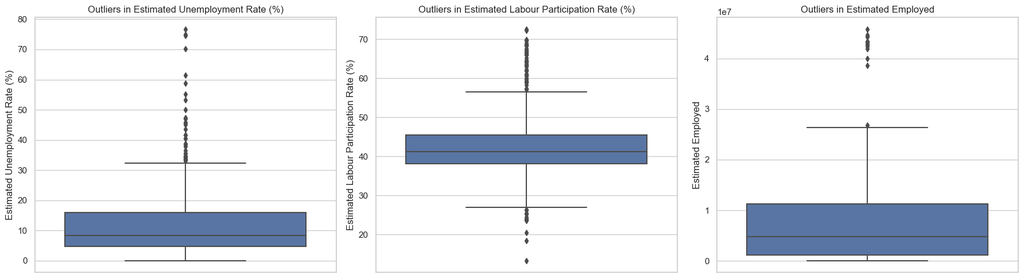

```
Outliers in 'Estimated Unemployment Rate (%)': (35 rows)
     Estimated Unemployment Rate (%)   Region         Date
37                             45.09    Bihar   30-04-2020
38                             47.26    Bihar   31-05-2020
105                            41.61  Haryana   30-04-2020
106                            34.22  Haryana   31-05-2020
107                            35.57  Haryana   30-06-2020

Outliers in 'Estimated Labour Participation Rate (%)': (63 rows)
     Estimated Labour Participation Rate (%)            Region         Date
14                                     57.39             Assam   31-05-2019
119                                    18.43  Himachal Pradesh   30-04-2020
172                                    13.33            Kerala   30-04-2020
203                                    66.13         Meghalaya   31-05-2019
204                                    61.09         Meghalaya   30-06-2019

Outliers in 'Estimated Employed': (15 rows)
     Estimated Employed         Region         Date
192          26835389.0    Maharashtra   31-08-2019
318          43287808.0  Uttar Pradesh   31-05-2019
319          42276572.0  Uttar Pradesh   30-06-2019
320          42697000.0  Uttar Pradesh   31-07-2019
321          43298746.0  Uttar Pradesh   31-08-2019
```

```python
columns = ['Estimated Unemployment Rate (%)',
           'Estimated Labour Participation Rate (%)',
           'Estimated Employed']

plt.figure(figsize=(18, 5))
for i, col in enumerate(columns):
    plt.subplot(1, 3, i+1)
    sns.boxplot(y=df[col])
    plt.title(f'Outliers in {col}')
plt.tight_layout()
plt.show()

def find_outliers_iqr(data, column):
    Q1 = data[column].quantile(0.25)
    Q3 = data[column].quantile(0.75)
    IQR = Q3 - Q1
    lower_bound = Q1 - 1.5 * IQR
    upper_bound = Q3 + 1.5 * IQR
    return data[(data[column] < lower_bound) | (data[column] > upper_bound)]

for col in columns:
    outliers = find_outliers_iqr(df, col)
    print(f"\nOutliers in '{col}': ({len(outliers)} rows)")
    print(outliers[[col, 'Region', 'Date']].head())
```

#### ◈ We can see that there are some outliers but they are not such extreme values. We also cannot remove those values as we need those to analyse the real trend in unemployment. Because of these values only we can see the sudden growth or decline in the unemployment rate in a particular region.

### ◎ Converting Date to datetime & Extracting Year and Month from Date :

```python
df['Date']=pd.to_datetime(df['Date'])
```

```python
df
```

|  | Region | Date | Frequency | Estimated Unemployment Rate (%) | Estimated Employed | Estimated Labour Participation Rate (%) | Area |
| --- | --- | --- | --- | --- | --- | --- | --- |
| 0 | Andhra Pradesh | 2019-05-31 | Monthly | 3.65 | 11999139.0 | 43.24 | Rural |
| 1 | Andhra Pradesh | 2019-06-30 | Monthly | 3.05 | 11755881.0 | 42.05 | Rural |
| 2 | Andhra Pradesh | 2019-07-31 | Monthly | 3.75 | 12086707.0 | 43.50 | Rural |
| 3 | Andhra Pradesh | 2019-08-31 | Monthly | 3.32 | 12285693.0 | 43.97 | Rural |
| 4 | Andhra Pradesh | 2019-09-30 | Monthly | 5.17 | 12256762.0 | 44.68 | Rural |
| ... | ... | ... | ... | ... | ... | ... | ... |
| 749 | West Bengal | 2020-02-29 | Monthly | 7.55 | 10871168.0 | 44.09 | Urban |
| 750 | West Bengal | 2020-03-31 | Monthly | 6.67 | 10806105.0 | 43.34 | Urban |
| 751 | West Bengal | 2020-04-30 | Monthly | 15.63 | 9299466.0 | 41.20 | Urban |
| 752 | West Bengal | 2020-05-31 | Monthly | 15.22 | 9240903.0 | 40.67 | Urban |
| 753 | West Bengal | 2020-06-30 | Monthly | 9.86 | 9088931.0 | 37.57 | Urban |

740 rows × 7 columns

```python
df['Year'] = df['Date'].dt.year
```

```python
df
```

|  | Region | Date | Frequency | Estimated Unemployment Rate (%) | Estimated Employed | Estimated Labour Participation Rate (%) | Area | Year |
| --- | --- | --- | --- | --- | --- | --- | --- | --- |
| 0 | Andhra Pradesh | 2019-05-31 | Monthly | 3.65 | 11999139.0 | 43.24 | Rural | 2019 |
| 1 | Andhra Pradesh | 2019-06-30 | Monthly | 3.05 | 11755881.0 | 42.05 | Rural | 2019 |
| 2 | Andhra Pradesh | 2019-07-31 | Monthly | 3.75 | 12086707.0 | 43.50 | Rural | 2019 |
| 3 | Andhra Pradesh | 2019-08-31 | Monthly | 3.32 | 12285693.0 | 43.97 | Rural | 2019 |
| 4 | Andhra Pradesh | 2019-09-30 | Monthly | 5.17 | 12256762.0 | 44.68 | Rural | 2019 |
| ... | ... | ... | ... | ... | ... | ... | ... | ... |
| 749 | West Bengal | 2020-02-29 | Monthly | 7.55 | 10871168.0 | 44.09 | Urban | 2020 |
| 750 | West Bengal | 2020-03-31 | Monthly | 6.67 | 10806105.0 | 43.34 | Urban | 2020 |
| 751 | West Bengal | 2020-04-30 | Monthly | 15.63 | 9299466.0 | 41.20 | Urban | 2020 |
| 752 | West Bengal | 2020-05-31 | Monthly | 15.22 | 9240903.0 | 40.67 | Urban | 2020 |
| 753 | West Bengal | 2020-06-30 | Monthly | 9.86 | 9088931.0 | 37.57 | Urban | 2020 |

740 rows × 8 columns

```python
df['Month'] = df['Date'].dt.month
```

```python
df
```

|  | Region | Date | Frequency | Estimated Unemployment Rate (%) | Estimated Employed | Estimated Labour Participation Rate (%) | Area | Year | Month |
| --- | --- | --- | --- | --- | --- | --- | --- | --- | --- |
| 0 | Andhra Pradesh | 2019-05-31 | Monthly | 3.65 | 11999139.0 | 43.24 | Rural | 2019 | 5 |
| 1 | Andhra Pradesh | 2019-06-30 | Monthly | 3.05 | 11755881.0 | 42.05 | Rural | 2019 | 6 |
| 2 | Andhra Pradesh | 2019-07-31 | Monthly | 3.75 | 12086707.0 | 43.50 | Rural | 2019 | 7 |
| 3 | Andhra Pradesh | 2019-08-31 | Monthly | 3.32 | 12285693.0 | 43.97 | Rural | 2019 | 8 |
| 4 | Andhra Pradesh | 2019-09-30 | Monthly | 5.17 | 12256762.0 | 44.68 | Rural | 2019 | 9 |
| ... | ... | ... | ... | ... | ... | ... | ... | ... | ... |
| 749 | West Bengal | 2020-02-29 | Monthly | 7.55 | 10871168.0 | 44.09 | Urban | 2020 | 2 |
| 750 | West Bengal | 2020-03-31 | Monthly | 6.67 | 10806105.0 | 43.34 | Urban | 2020 | 3 |
| 751 | West Bengal | 2020-04-30 | Monthly | 15.63 | 9299466.0 | 41.20 | Urban | 2020 | 4 |
| 752 | West Bengal | 2020-05-31 | Monthly | 15.22 | 9240903.0 | 40.67 | Urban | 2020 | 5 |
| 753 | West Bengal | 2020-06-30 | Monthly | 9.86 | 9088931.0 | 37.57 | Urban | 2020 | 6 |

740 rows × 9 columns

```python
df = df[['Region', 'Date', 'Year', 'Month', 'Frequency', 'Estimated Unemployment Rate (%)',
       'Estimated Employed', 'Estimated Labour Participation Rate (%)', 'Area',
       ]]
df
```

|  | Region | Date | Year | Month | Frequency | Estimated Unemployment Rate (%) | Estimated Employed | Estimated Labour Participation Rate (%) | Area |
| --- | --- | --- | --- | --- | --- | --- | --- | --- | --- |
| 0 | Andhra Pradesh | 2019-05-31 | 2019 | 5 | Monthly | 3.65 | 11999139.0 | 43.24 | Rural |
| 1 | Andhra Pradesh | 2019-06-30 | 2019 | 6 | Monthly | 3.05 | 11755881.0 | 42.05 | Rural |
| 2 | Andhra Pradesh | 2019-07-31 | 2019 | 7 | Monthly | 3.75 | 12086707.0 | 43.50 | Rural |
| 3 | Andhra Pradesh | 2019-08-31 | 2019 | 8 | Monthly | 3.32 | 12285693.0 | 43.97 | Rural |
| 4 | Andhra Pradesh | 2019-09-30 | 2019 | 9 | Monthly | 5.17 | 12256762.0 | 44.68 | Rural |
| ... | ... | ... | ... | ... | ... | ... | ... | ... | ... |
| 749 | West Bengal | 2020-02-29 | 2020 | 2 | Monthly | 7.55 | 10871168.0 | 44.09 | Urban |
| 750 | West Bengal | 2020-03-31 | 2020 | 3 | Monthly | 6.67 | 10806105.0 | 43.34 | Urban |
| 751 | West Bengal | 2020-04-30 | 2020 | 4 | Monthly | 15.63 | 9299466.0 | 41.20 | Urban |
| 752 | West Bengal | 2020-05-31 | 2020 | 5 | Monthly | 15.22 | 9240903.0 | 40.67 | Urban |
| 753 | West Bengal | 2020-06-30 | 2020 | 6 | Monthly | 9.86 | 9088931.0 | 37.57 | Urban |

740 rows × 9 columns

### ◎ Adding derived feature 'Rural - Urban Gap' for Estimated Unemployment Rate (%), Estimated Employed, Estimated Labour Participation Rate (%) :

```python
pivot_all = df.pivot_table(
    index=['Region', 'Date'],
    columns='Area',
    values=[
        'Estimated Unemployment Rate (%)',
        'Estimated Employed',
        'Estimated Labour Participation Rate (%)'
    ]
).reset_index()

pivot_all.columns = ['Region', 'Date',
    'Employed_Rural', 'Employed_Urban',
    'LPR_Rural', 'LPR_Urban',
    'Unemployment_Rural', 'Unemployment_Urban'
]

pivot_all['Gap_Unemployment %'] = pivot_all['Unemployment_Rural'] - pivot_all['Unemployment_Urban']
pivot_all['Gap_Employed'] = pivot_all['Employed_Rural'] - pivot_all['Employed_Urban']
pivot_all['Gap_Labour_Participation %'] = pivot_all['LPR_Rural'] - pivot_all['LPR_Urban']

df = df.merge(
    pivot_all[['Region', 'Date', 'Gap_Unemployment %', 'Gap_Employed', 'Gap_Labour_Participation %']],
    on=['Region', 'Date'],
    how='left'
)

df
```

|  | Region | Date | Year | Month | Frequency | Estimated Unemployment Rate (%) | Estimated Employed | Estimated Labour Participation Rate (%) | Area | Gap_Unemployment % | Gap_Employed | Gap_Labour_Participation % |
| --- | --- | --- | --- | --- | --- | --- | --- | --- | --- | --- | --- | --- |
| 0 | Andhra Pradesh | 2019-05-31 | 2019 | 5 | Monthly | 3.65 | 11999139.0 | 43.24 | Rural | -2.44 | 7210478.0 | 5.79 |
| 1 | Andhra Pradesh | 2019-06-30 | 2019 | 6 | Monthly | 3.05 | 11755881.0 | 42.05 | Rural | -0.75 | 6931251.0 | 5.29 |
| 2 | Andhra Pradesh | 2019-07-31 | 2019 | 7 | Monthly | 3.75 | 12086707.0 | 43.50 | Rural | -1.89 | 7429264.0 | 7.40 |
| 3 | Andhra Pradesh | 2019-08-31 | 2019 | 8 | Monthly | 3.32 | 12285693.0 | 43.97 | Rural | -1.29 | 7542514.0 | 7.68 |
| 4 | Andhra Pradesh | 2019-09-30 | 2019 | 9 | Monthly | 5.17 | 12256762.0 | 44.68 | Rural | -0.84 | 7522766.0 | 7.99 |
| ... | ... | ... | ... | ... | ... | ... | ... | ... | ... | ... | ... | ... |
| 735 | West Bengal | 2020-02-29 | 2020 | 2 | Monthly | 7.55 | 10871168.0 | 44.09 | Urban | -3.77 | 15221841.0 | 5.42 |
| 736 | West Bengal | 2020-03-31 | 2020 | 3 | Monthly | 6.67 | 10806105.0 | 43.34 | Urban | 0.35 | 14291707.0 | 5.84 |
| 737 | West Bengal | 2020-04-30 | 2020 | 4 | Monthly | 15.63 | 9299466.0 | 41.20 | Urban | 2.69 | 8339904.0 | -1.93 |
| 738 | West Bengal | 2020-05-31 | 2020 | 5 | Monthly | 15.22 | 9240903.0 | 40.67 | Urban | 3.21 | 9874869.0 | 1.86 |
| 739 | West Bengal | 2020-06-30 | 2020 | 6 | Monthly | 9.86 | 9088931.0 | 37.57 | Urban | -4.92 | 12136956.0 | 2.87 |

740 rows × 12 columns

### ◎ Adding Derived Feature 'MoM Change' in Estimated Unemployment Rate (%) :

```python
df["Original_Order"] = range(len(df))

df["MoM_Unemployment_Rate_Change"] = (
    df.groupby("Region")["Estimated Unemployment Rate (%)"]
    .diff()
)

df = df.sort_values("Original_Order").drop(columns="Original_Order")

df
```

|  | Region | Date | Year | Month | Frequency | Estimated Unemployment Rate (%) | Estimated Employed | Estimated Labour Participation Rate (%) | Area | Gap_Unemployment % | Gap_Employed | Gap_Labour_Participation % | MoM_Unemployment_Rate_Change |
| --- | --- | --- | --- | --- | --- | --- | --- | --- | --- | --- | --- | --- | --- |
| 0 | Andhra Pradesh | 2019-05-31 | 2019 | 5 | Monthly | 3.65 | 11999139.0 | 43.24 | Rural | -2.44 | 7210478.0 | 5.79 | NaN |
| 1 | Andhra Pradesh | 2019-06-30 | 2019 | 6 | Monthly | 3.05 | 11755881.0 | 42.05 | Rural | -0.75 | 6931251.0 | 5.29 | -0.60 |
| 2 | Andhra Pradesh | 2019-07-31 | 2019 | 7 | Monthly | 3.75 | 12086707.0 | 43.50 | Rural | -1.89 | 7429264.0 | 7.40 | 0.70 |
| 3 | Andhra Pradesh | 2019-08-31 | 2019 | 8 | Monthly | 3.32 | 12285693.0 | 43.97 | Rural | -1.29 | 7542514.0 | 7.68 | -0.43 |
| 4 | Andhra Pradesh | 2019-09-30 | 2019 | 9 | Monthly | 5.17 | 12256762.0 | 44.68 | Rural | -0.84 | 7522766.0 | 7.99 | 1.85 |
| ... | ... | ... | ... | ... | ... | ... | ... | ... | ... | ... | ... | ... | ... |
| 735 | West Bengal | 2020-02-29 | 2020 | 2 | Monthly | 7.55 | 10871168.0 | 44.09 | Urban | -3.77 | 15221841.0 | 5.42 | 0.28 |
| 736 | West Bengal | 2020-03-31 | 2020 | 3 | Monthly | 6.67 | 10806105.0 | 43.34 | Urban | 0.35 | 14291707.0 | 5.84 | -0.88 |
| 737 | West Bengal | 2020-04-30 | 2020 | 4 | Monthly | 15.63 | 9299466.0 | 41.20 | Urban | 2.69 | 8339904.0 | -1.93 | 8.96 |
| 738 | West Bengal | 2020-05-31 | 2020 | 5 | Monthly | 15.22 | 9240903.0 | 40.67 | Urban | 3.21 | 9874869.0 | 1.86 | -0.41 |
| 739 | West Bengal | 2020-06-30 | 2020 | 6 | Monthly | 9.86 | 9088931.0 | 37.57 | Urban | -4.92 | 12136956.0 | 2.87 | -5.36 |

740 rows × 13 columns

## ⚫ SECTION B: SQL Operations

- Import cleaned data into SQLite or pandasql environment.
- Example SQL queries:
  - Top 5 regions with highest average unemployment rate during 2020–21
  - Compare participation rates between rural and urban regions
  - Query regional unemployment trends over years
  - Identify regions with greatest improvement post-2020
  - Count months/years where unemployment rate exceeded national average

### SQL Queries:

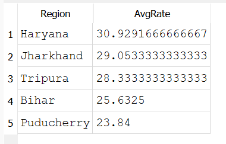

Insights :-

☑ It helps highlight which areas were most economically impacted in terms of employment during COVID-19.

☑ Use Case: Useful for government agencies to target job recovery programs.

#### 2. Compare participation rates between rural and urban regions

SELECT Area, AVG("Estimated Labour Participation Rate (%)") AS AvgParticipation FROM 'Unemployment in India' GROUP BY Area;

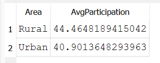

Insights :-

☑ Shows average labor participation for rural vs urban areas.

☑ Typically:

• Rural areas may reflect seasonal variations based on agriculture.

• Helps assess employment engagement across different living environments.

#### 3. Query regional unemployment trends over years

SELECT Region, substr(Date, 1, 4) AS Year, AVG("Estimated Unemployment Rate (%)") AS AvgRate FROM 'Unemployment in India' GROUP BY Region, Year ORDER BY Region, Year;

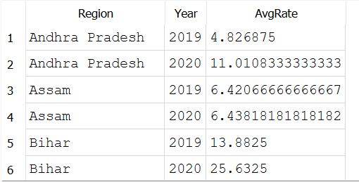

Insights :-

☑ Displays year-wise unemployment rates for each region.

☑ Shows if regions are:

• Improving (rates decreasing)

• Worsening

☑ Helps in understanding long-term economic trends across states.

#### 4. Identify regions with greatest improvement post-2020

WITH Pre2019 AS ( SELECT Region, AVG("Estimated Unemployment Rate (%)") AS AvgPre FROM 'Unemployment in India' WHERE substr(Date, 1, 4) = '2019' GROUP BY Region ), Post2019 AS ( SELECT Region, AVG("Estimated Unemployment Rate (%)") AS AvgPost FROM 'Unemployment in India' WHERE substr(Date, 1, 4) >= '2020' GROUP BY Region ) SELECT p.Region, p.AvgPre, q.AvgPost, (p.AvgPre - q.AvgPost) AS Improvement FROM Pre2019 p JOIN Post2019 q ON p.Region = q.Region ORDER BY Improvement DESC;

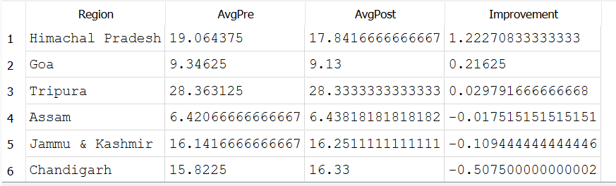

Insights :-

☑ Ranks regions that reduced their unemployment rate the most after 2019.

☑ Highlights successful regional economic recovery.

☑ Use Case: Study policies or industries that drove recovery in those areas.

#### 5. Count months/years where unemployment rate exceeded national average

WITH NationalAvg AS ( SELECT substr(Date, 1, 7) AS MonthYear, AVG("Estimated Unemployment Rate (%)") AS NatAvg FROM 'Unemployment in India' GROUP BY substr(Date, 1, 7) ) SELECT u.Region, COUNT(*) AS CountExceeding FROM 'Unemployment in India' u JOIN NationalAvg n ON substr(u.Date, 1, 7) = n.MonthYear WHERE u."Estimated Unemployment Rate (%)" > n.NatAvg GROUP BY u.Region ORDER BY CountExceeding DESC;

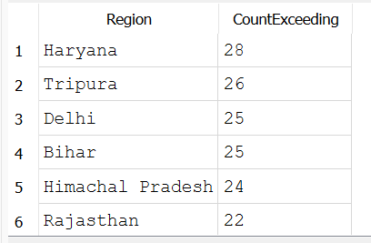

Insights :-

☑ Counts how many region-months had unemployment above national average.

☑ Indicates frequency of economic stress in specific areas.

☑ Helps in regional performance benchmarking against national trends.

## ⚫SECTION C: EDA & Descriptive Statistics

### ◎ Exploratory Data Analysis :

- Line charts of unemployment rate over time for select states (e.g., Delhi, Maharashtra)
- Bar charts comparing rural vs urban unemployment rates
- Heatmap: region × year showing unemployment intensity
- Box plots: participation rate distribution across regions
- Time series of employment and participation rates

#### 1. Unemployment Rate Over Time For Select States Line Chart

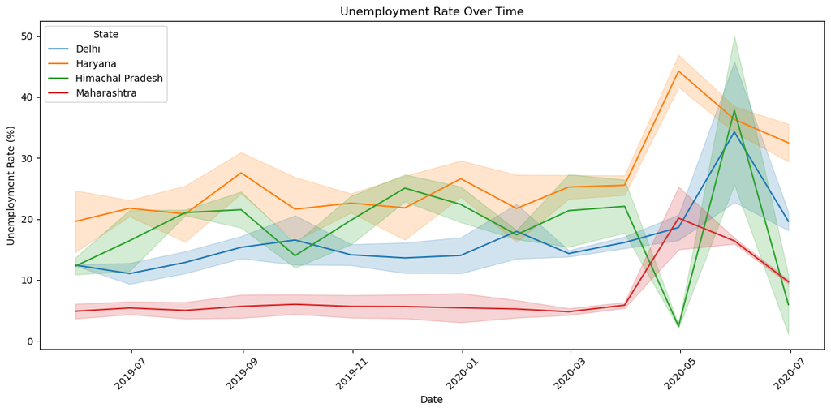

```python
states = ['Delhi', 'Maharashtra', 'Himachal Pradesh', 'Haryana']
subset = df[df['Region'].isin(states)]

plt.figure(figsize=(12, 6))
sns.lineplot(data=subset, x='Date', y='Estimated Unemployment Rate (%)', hue='Region')
plt.title("Unemployment Rate Over Time")
plt.xlabel("Date")
plt.ylabel("Unemployment Rate (%)")
plt.legend(title='State')
plt.xticks(rotation=45)
plt.tight_layout()
plt.show()
```

#### Analysis:

- Delhi: Highly unstable, sharp COVID-19 spike, slow and inconsistent recovery due to urban informality and shocks in the service sector.
- Maharashtra: Mostly stable before COVID; major spike during lockdown, but quick recovery later, showing industrial and economic diversity.
- Haryana: Consistently high, worsened during COVID; highlights deep, ongoing issues in the rural economy and a lack of non-farm jobs.
- Himachal Pradesh: Significant seasonality, sudden drops during crises related to seasonal work, migration, and tourism cycles.

#### 2. Bar charts comparing rural vs urban unemployment rates

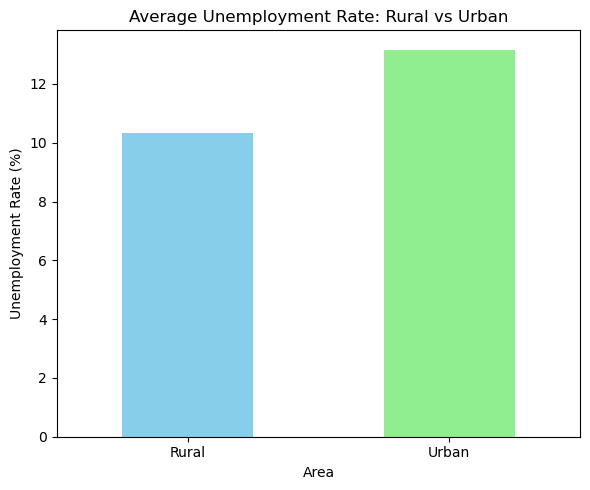

```python
if 'Area' in df.columns:
    area_group = df.groupby('Area')['Estimated Unemployment Rate (%)'].mean()
    area_group.plot(kind='bar', color=['skyblue', 'lightgreen'], figsize=(6, 5))
    plt.title('Average Unemployment Rate: Rural vs Urban')
    plt.ylabel('Unemployment Rate (%)')
    plt.xticks(rotation=0)
    plt.tight_layout()
    plt.show()
else:
    print("No 'Area' column found for Rural vs Urban comparison.")
```

#### Analysis:

- Urban unemployment has consistently been higher, especially during COVID peaks; cities lost most jobs during lockdown.
- Rural areas experienced a smaller, more moderate increase, with quicker recovery, partly due to reliance on farming and rural programs.
- Reasons:
  - Urban areas rely more on services, contract jobs, and daily wage work, making them vulnerable to shutdowns.
  - Rural employment is less diversified but somewhat more resilient in emergencies.

### 3. Heatmap: region × year showing unemployment intensity

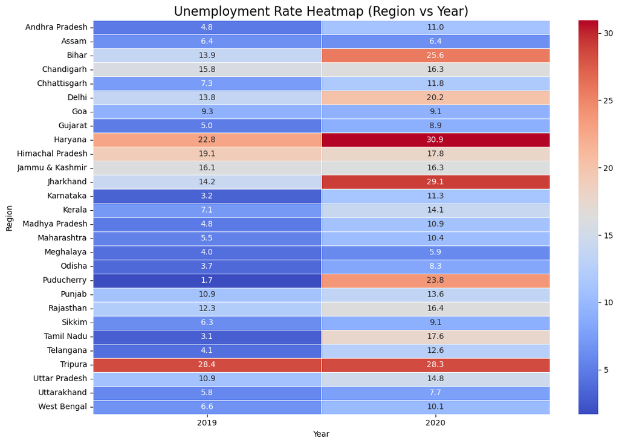

```python
df['Date'] = pd.to_datetime(df['Date'])

heatmap_data = df.groupby(['Region', 'Year'])['Estimated Unemployment Rate (%)'].mean().unstack()

plt.figure(figsize=(12, 8))
sns.heatmap(heatmap_data, annot=True, cmap='coolwarm', fmt=".1f", linewidths=.5)
plt.title('Unemployment Rate Heatmap (Region vs Year)', fontsize=16)
plt.xlabel('Year')
plt.ylabel('Region')
plt.tight_layout()
plt.show()
```

#### 4. Box plots: participation rate distribution across regions

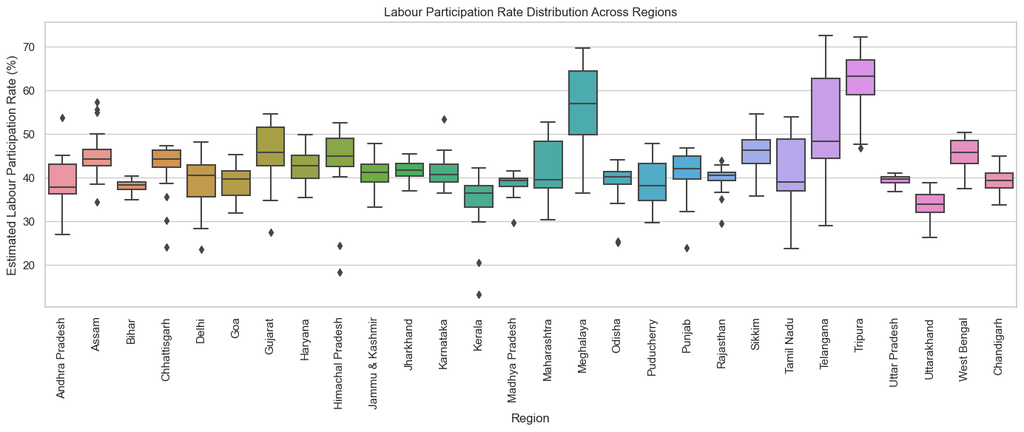

```python
plt.figure(figsize=(14, 6))
sns.set(style="whitegrid")

sns.boxplot(data=df, x='Region', y='Estimated Labour Participation Rate (%)')

plt.xticks(rotation=90)
plt.title('Labour Participation Rate Distribution Across Regions')
plt.xlabel('Region')
plt.ylabel('Estimated Labour Participation Rate (%)')
plt.tight_layout()

plt.show()
```

#### 5. Time series of employment and participation rates

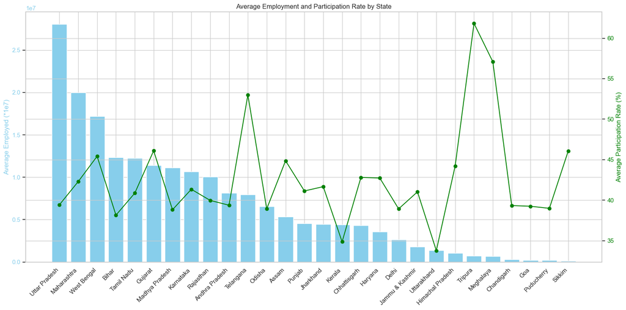

```python
import pandas as pd
import matplotlib.pyplot as plt

state_avg = df.groupby("Region").agg({
    "Estimated Employed": "mean",
    "Estimated Labour Participation Rate (%)": "mean"
}).reset_index()

state_avg = state_avg.sort_values(by="Estimated Employed", ascending=False)

fig, ax1 = plt.subplots(figsize=(16, 8))

bar1 = ax1.bar(state_avg['Region'], state_avg['Estimated Employed'], color='skyblue', label='Avg Employed')
ax1.set_ylabel('Average Employed (*1e7)', color='skyblue')
ax1.tick_params(axis='y', labelcolor='skyblue')
ax1.set_xticklabels(state_avg['Region'], rotation=45, ha='right')

ax2 = ax1.twinx()
line1 = ax2.plot(state_avg['Region'], state_avg['Estimated Labour Participation Rate (%)'], color='green', marker='o', label='Avg Participation Rate')
ax2.set_ylabel('Average Participation Rate (%)', color='green')
ax2.tick_params(axis='y', labelcolor='green')

plt.title('Average Employment and Participation Rate by State')
fig.tight_layout()
plt.show()
```

#### Overall Real World Insights:

- COVID-19 was the largest shock, worsening both urban and rural labor market weaknesses.
- Urban jobs are far more vulnerable to shocks than rural jobs due to greater informality and fewer fallback options.
- Ongoing issues in places like Haryana existed before COVID, highlighting youth unemployment and insufficient job creation.
- Women and young people face the most challenges during downturns and often leave the workforce.
- States with diverse economies, like Maharashtra, recover faster from shocks.

### ◎ Descriptive Statistics :

- Mean, median, standard deviation for unemployment and participation
- Compute coefficient of variation by region
- Rank top 3 states with highest variability in unemployment
- Identify months/years with extreme peaks or dips aka outliers (IQR method)
- Calculate correlation between unemployment rate and participation rate

#### 1. Mean, median, standard deviation for unemployment and participation

```python
m1 = df['Estimated Unemployment Rate (%)'].mean()
med1 = df['Estimated Unemployment Rate (%)'].median()
sd1 = np.std(df['Estimated Unemployment Rate (%)'])

print(f"Mean of Estimated Unemployment Rate (%): {m1:.2f} ")
print(f"Median of Estimated Unemployment Rate (%): {med1:.2f} ")
print(f"Standard Deviation of Estimated Unemployment Rate (%): {sd1:.2f} ")
```

```
Mean of Estimated Unemployment Rate (%): 11.79
Median of Estimated Unemployment Rate (%): 8.35
Standard Deviation of Estimated Unemployment Rate (%): 10.71
```

```python
m2 = df['Estimated Labour Participation Rate (%)'].mean()
med2 = df['Estimated Labour Participation Rate (%)'].median()
sd2 = np.std(df['Estimated Labour Participation Rate (%)'])

print(f"Mean of Estimated Labour Participation Rate (%): {m2:.2f} ")
print(f"Median of Estimated Labour Participation Rate (%): {med2:.2f} ")
print(f"Standard Deviation of Estimated Labour Participation Rate (%): {sd2:.2f} ")
```

```
Mean of Estimated Labour Participation Rate (%): 42.63
Median of Estimated Labour Participation Rate (%): 41.16
Standard Deviation of Estimated Labour Participation Rate (%): 8.11
```

#### Insights:

- If the mean ≠ median, the data might be skewed (e.g., some states or months with unusually high or low rates).
- A high standard deviation in unemployment means inconsistency — possible job instability or seasonal effects.
- A low standard deviation in participation rate suggests workforce involvement is stable.

#### Use Cases:

- Helps compare states or plan employment programs where variability is high.
- Useful in understanding labor market stability.

#### 2. Compute coefficient of variation by region

```python
df.columns = df.columns.str.strip()
cv_by_region = df.groupby('Region')['Estimated Unemployment Rate (%)'].agg(['mean', 'std'])
cv_by_region['CV (%)'] = (cv_by_region['std'] / cv_by_region['mean']) * 100
cv_by_region
```

| Region | mean | std | CV (%) |
| --- | --- | --- | --- |
| Andhra Pradesh | 7.477143 | 6.852073 | 91.640263 |
| Assam | 6.428077 | 3.008218 | 46.798104 |
| Bihar | 18.918214 | 12.634987 | 66.787420 |
| Chandigarh | 15.991667 | 5.508220 | 34.444315 |
| Chhattisgarh | 9.240357 | 5.810302 | 62.879621 |
| Delhi | 16.495357 | 6.788172 | 41.152015 |
| Goa | 9.274167 | 7.036178 | 75.868573 |
| Gujarat | 6.663929 | 4.682053 | 70.259647 |
| Haryana | 26.283214 | 7.797119 | 29.665773 |
| Himachal Pradesh | 18.540357 | 9.607612 | 51.819995 |
| Jammu & Kashmir | 16.188571 | 5.506308 | 34.013554 |
| Jharkhand | 20.585000 | 16.674746 | 81.004352 |
| Karnataka | 6.676071 | 8.103508 | 121.381390 |
| Kerala | 10.123929 | 6.899331 | 68.148756 |
| Madhya Pradesh | 7.406429 | 7.757720 | 104.743058 |
| Maharashtra | 7.557500 | 5.063918 | 67.005198 |
| Meghalaya | 4.798889 | 4.102673 | 85.492144 |
| Odisha | 5.657857 | 5.553891 | 98.162448 |
| Puducherry | 10.215000 | 24.106816 | 235.994283 |
| Punjab | 12.031071 | 6.928660 | 57.589717 |
| Rajasthan | 14.058214 | 5.932577 | 42.200078 |
| Sikkim | 7.249412 | 5.790275 | 79.872338 |
| Tamil Nadu | 9.284286 | 14.455317 | 155.696595 |
| Telangana | 7.737857 | 8.544484 | 110.424419 |
| Tripura | 28.350357 | 6.058335 | 21.369520 |
| Uttar Pradesh | 12.551429 | 5.703357 | 45.439907 |
| Uttarakhand | 6.582963 | 3.321334 | 50.453483 |
| West Bengal | 8.124643 | 3.865715 | 47.580121 |

#### Insights:

- A high CV indicates a region with unstable unemployment — frequent highs and lows.
- A low CV means the unemployment rate is more consistent over time.

#### Use Case:

- Identify regions that need more consistent job opportunities or policy support.

#### 3. Rank top 3 states with highest variability in unemployment

```python
cv_by_region = df.groupby('Region')['Estimated Unemployment Rate (%)'].agg(['mean', 'std'])
cv_by_region['CV (%)'] = (cv_by_region['std'] / cv_by_region['mean']) * 100


top_3_cv_states = cv_by_region.sort_values(by='CV (%)', ascending=False).head(3)
print(top_3_cv_states)
```

```
                 mean        std      CV (%)
Region
Puducherry  10.215000  24.106816  235.994283
Tamil Nadu   9.284286  14.455317  155.696595
Karnataka    6.676071   8.103508  121.381390
```

#### What It Tells Us:

- These are the regions with the most unpredictable unemployment rates.

#### Insights:

- They may suffer from:
  - Seasonal employment (e.g., agriculture-based regions).
  - Policy failures or lack of industrial diversity.
  - Example: States with CV > 100% are highly volatile.

#### Use Case:

- Prioritize these states for economic diversification or job security programs

#### 4. Identify months/years with extreme peaks or dips aka outliers (IQR method)

```python
df['Date'] = pd.to_datetime(df['Date'])
df['Year'] = df['Date'].dt.year
df['Month'] = df['Date'].dt.month


Q1 = df['Estimated Unemployment Rate (%)'].quantile(0.25)
Q3 = df['Estimated Unemployment Rate (%)'].quantile(0.75)
IQR = Q3 - Q1


lower_bound = Q1 - 1.5 * IQR
upper_bound = Q3 + 1.5 * IQR


outliers = df[(df['Estimated Unemployment Rate (%)'] < lower_bound) |
              (df['Estimated Unemployment Rate (%)'] > upper_bound)]


print(outliers[['Date', 'Region', 'Estimated Unemployment Rate (%)']])
```

```
          Date            Region  Estimated Unemployment Rate (%)
37  2020-04-30             Bihar                            45.09
38  2020-05-31             Bihar                            47.26
105 2020-04-30           Haryana                            41.61
106 2020-05-31           Haryana                            34.22
107 2020-06-30           Haryana                            35.57
144 2020-04-30         Jharkhand                            41.72
145 2020-05-31         Jharkhand                            55.10
158 2020-04-30         Karnataka                            33.17
242 2020-04-30        Puducherry                            74.51
255 2020-05-31            Punjab                            40.59
287 2020-04-30        Tamil Nadu                            53.19
288 2020-05-31        Tamil Nadu                            38.73
302 2020-05-31         Telangana                            34.01
315 2020-04-30           Tripura                            43.64
```

[output cut: 21 more lines]

#### What It Tells Us:

- IQR helps find months or years where unemployment spiked or dropped unusually.
- Outliers are typically policy-impacting events, like:
  - COVID-19 in 2020 (mass unemployment).
  - Festivals/agriculture seasons (high temporary employment).

#### Insights:

- Spotting these helps understand when and why the labor market behaves abnormally.

#### Use Case:

- Helps evaluate effectiveness of employment schemes or economic shocks.
- Good for designing early warning systems for unemployment surges.

#### 5. Calculate correlation between unemployment rate and participation rate

```python
correlation = df['Estimated Unemployment Rate (%)'].corr(df['Estimated Labour Participation Rate (%)'])

print(f"Correlation between Unemployment Rate and Participation Rate: {correlation:.4f}")
```

```
Correlation between Unemployment Rate and Participation Rate: 0.0026
```

#### Insights:

- Participation doesn’t strongly influence unemployment in this dataset.
- Other factors (education, industry presence, migration) likely play a bigger role.

#### Use Case:

- Suggests that policies should target more than just increasing participation — like job creation or skills training.

## ⚫ SECTION D: Tableau Dashboard

- Interactive map of India showing unemployment rates by state per year
- Filters: Region type (rural/urban), Year, Month
- Line chart of unemployment trends per region
- Bar chart comparison of participation vs unemployment by region
- KPI cards: highest unemployment rate, average participation
- Heatmap: region vs year unemployment values
- Trend absorber: highlight policy impact years like 2020

### ◈ Tableau Dashboard ◈

[figure not shown]

#### ✔ All-India Averages:

- Avg Unemployment Rate: 11.79%
- Urban vs Rural:
  - Urban: 13.17%
  - Rural: 10.32%
- Avg Labour Participation Rate: 42.63%

#### ✔ Highest Unemployment:

- The highest unemployment rate recorded is 76.74%, likely due to a policy or pandemic-related disruption.

#### ✔ Trend Analysis:

- Sharp spike around April–May 2020, aligning with policy impact or crisis (e.g., COVID-19 lockdown).
- Some states like Haryana and Bihar faced extreme spikes during that time.

#### ✔ Geographical Distribution:

- Northern and Central states like Haryana, Bihar, Himachal have higher average unemployment.
- Southern and Eastern states (like Odisha, Maharashtra) show lower rates.

## ⚫ SECTION E: Machine Learning

- Regression Task
  - Forecast future unemployment rate (e.g., for 2020-2021) using features such as:
    - Current & previous rates, participation rate, region type
  - Models: Linear Regression or Random Forest Regressor
- Classification Task
  - Categorize unemployment rate into buckets: Low (<5%), Medium (5–10%), High (>10%)
  - Train models: Logistic Regression, Decision Tree, Random Forest
  - Feature importance to identify drivers of high unemployment

```python
df.isnull().sum()
```

```
Region                                      0
Date                                        0
Year                                        0
Month                                       0
Frequency                                   0
Estimated Unemployment Rate (%)             0
Estimated Employed                          0
Estimated Labour Participation Rate (%)     0
Area                                        0
Gap_Unemployment %                         30
Gap_Employed                               30
Gap_Labour_Participation %                 30
MoM_Unemployment_Rate_Change               28
dtype: int64
```

```python
x = df[df['Gap_Unemployment %'].isnull()]
x['Region'].value_counts() # regions that has null values in 'Gap_Unemployment %'
```

```
Chandigarh         12
Sikkim              7
Jammu & Kashmir     3
Goa                 2
Assam               2
Puducherry          2
Meghalaya           1
Uttarakhand         1
Name: Region, dtype: int64
```

```python
df1 = df.copy()
df1 = df1[['Region','Area',
            'Month',
           'Year' , 'Estimated Employed', 'Estimated Labour Participation Rate (%)', 'Gap_Employed' , 'MoM_Unemployment_Rate_Change'
           , 'Gap_Labour_Participation %'
           ,'Estimated Unemployment Rate (%)']]
df1
```

|  | Region | Area | Month | Year | Estimated Employed | Estimated Labour Participation Rate (%) | Gap_Employed | MoM_Unemployment_Rate_Change | Gap_Labour_Participation % | Estimated Unemployment Rate (%) |
| --- | --- | --- | --- | --- | --- | --- | --- | --- | --- | --- |
| 0 | Andhra Pradesh | Rural | 5 | 2019 | 11999139.0 | 43.24 | 7210478.0 | NaN | 5.79 | 3.65 |
| 1 | Andhra Pradesh | Rural | 6 | 2019 | 11755881.0 | 42.05 | 6931251.0 | -0.60 | 5.29 | 3.05 |
| 2 | Andhra Pradesh | Rural | 7 | 2019 | 12086707.0 | 43.50 | 7429264.0 | 0.70 | 7.40 | 3.75 |
| 3 | Andhra Pradesh | Rural | 8 | 2019 | 12285693.0 | 43.97 | 7542514.0 | -0.43 | 7.68 | 3.32 |
| 4 | Andhra Pradesh | Rural | 9 | 2019 | 12256762.0 | 44.68 | 7522766.0 | 1.85 | 7.99 | 5.17 |
| ... | ... | ... | ... | ... | ... | ... | ... | ... | ... | ... |
| 735 | West Bengal | Urban | 2 | 2020 | 10871168.0 | 44.09 | 15221841.0 | 0.28 | 5.42 | 7.55 |
| 736 | West Bengal | Urban | 3 | 2020 | 10806105.0 | 43.34 | 14291707.0 | -0.88 | 5.84 | 6.67 |
| 737 | West Bengal | Urban | 4 | 2020 | 9299466.0 | 41.20 | 8339904.0 | 8.96 | -1.93 | 15.63 |
| 738 | West Bengal | Urban | 5 | 2020 | 9240903.0 | 40.67 | 9874869.0 | -0.41 | 1.86 | 15.22 |
| 739 | West Bengal | Urban | 6 | 2020 | 9088931.0 | 37.57 | 12136956.0 | -5.36 | 2.87 | 9.86 |

740 rows × 10 columns

```python
name_change = {
    'Estimated Labour Participation Rate (%)' : "Participation Rate",
    'Estimated Unemployment Rate (%)': "Unemployment Rate"
}

df1.rename(columns = name_change, inplace = True)
df1
```

|  | Region | Area | Month | Year | Estimated Employed | Participation Rate | Gap_Employed | MoM_Unemployment_Rate_Change | Gap_Labour_Participation % | Unemployment Rate |
| --- | --- | --- | --- | --- | --- | --- | --- | --- | --- | --- |
| 0 | Andhra Pradesh | Rural | 5 | 2019 | 11999139.0 | 43.24 | 7210478.0 | NaN | 5.79 | 3.65 |
| 1 | Andhra Pradesh | Rural | 6 | 2019 | 11755881.0 | 42.05 | 6931251.0 | -0.60 | 5.29 | 3.05 |
| 2 | Andhra Pradesh | Rural | 7 | 2019 | 12086707.0 | 43.50 | 7429264.0 | 0.70 | 7.40 | 3.75 |
| 3 | Andhra Pradesh | Rural | 8 | 2019 | 12285693.0 | 43.97 | 7542514.0 | -0.43 | 7.68 | 3.32 |
| 4 | Andhra Pradesh | Rural | 9 | 2019 | 12256762.0 | 44.68 | 7522766.0 | 1.85 | 7.99 | 5.17 |
| ... | ... | ... | ... | ... | ... | ... | ... | ... | ... | ... |
| 735 | West Bengal | Urban | 2 | 2020 | 10871168.0 | 44.09 | 15221841.0 | 0.28 | 5.42 | 7.55 |
| 736 | West Bengal | Urban | 3 | 2020 | 10806105.0 | 43.34 | 14291707.0 | -0.88 | 5.84 | 6.67 |
| 737 | West Bengal | Urban | 4 | 2020 | 9299466.0 | 41.20 | 8339904.0 | 8.96 | -1.93 | 15.63 |
| 738 | West Bengal | Urban | 5 | 2020 | 9240903.0 | 40.67 | 9874869.0 | -0.41 | 1.86 | 15.22 |
| 739 | West Bengal | Urban | 6 | 2020 | 9088931.0 | 37.57 | 12136956.0 | -5.36 | 2.87 | 9.86 |

740 rows × 10 columns

```python
# df1 = df1[~(df["Gap_Labour_Participation %"].isnull())]
df1 = df1[~(df["MoM_Unemployment_Rate_Change"].isnull())]
round(df1.isnull().sum()/len(df1)*100 , 2)
```

```
Region                          0.00
Area                            0.00
Month                           0.00
Year                            0.00
Estimated Employed              0.00
Participation Rate              0.00
Gap_Employed                    4.07
MoM_Unemployment_Rate_Change    0.00
Gap_Labour_Participation %      4.07
Unemployment Rate               0.00
dtype: float64
```

```python
x = df1[df1['Gap_Employed'].isnull()]
x['Region'].value_counts()
```

```
Chandigarh         11
Sikkim              7
Jammu & Kashmir     3
Goa                 2
Assam               2
Puducherry          2
Meghalaya           1
Uttarakhand         1
Name: Region, dtype: int64
```

```python
df1 = df1[~(df1['Gap_Employed'].isnull())]
df1
```

|  | Region | Area | Month | Year | Estimated Employed | Participation Rate | Gap_Employed | MoM_Unemployment_Rate_Change | Gap_Labour_Participation % | Unemployment Rate |
| --- | --- | --- | --- | --- | --- | --- | --- | --- | --- | --- |
| 1 | Andhra Pradesh | Rural | 6 | 2019 | 11755881.0 | 42.05 | 6931251.0 | -0.60 | 5.29 | 3.05 |
| 2 | Andhra Pradesh | Rural | 7 | 2019 | 12086707.0 | 43.50 | 7429264.0 | 0.70 | 7.40 | 3.75 |
| 3 | Andhra Pradesh | Rural | 8 | 2019 | 12285693.0 | 43.97 | 7542514.0 | -0.43 | 7.68 | 3.32 |
| 4 | Andhra Pradesh | Rural | 9 | 2019 | 12256762.0 | 44.68 | 7522766.0 | 1.85 | 7.99 | 5.17 |
| 5 | Andhra Pradesh | Rural | 10 | 2019 | 12017412.0 | 43.01 | 7243035.0 | -1.65 | 6.60 | 3.52 |
| ... | ... | ... | ... | ... | ... | ... | ... | ... | ... | ... |
| 735 | West Bengal | Urban | 2 | 2020 | 10871168.0 | 44.09 | 15221841.0 | 0.28 | 5.42 | 7.55 |
| 736 | West Bengal | Urban | 3 | 2020 | 10806105.0 | 43.34 | 14291707.0 | -0.88 | 5.84 | 6.67 |
| 737 | West Bengal | Urban | 4 | 2020 | 9299466.0 | 41.20 | 8339904.0 | 8.96 | -1.93 | 15.63 |
| 738 | West Bengal | Urban | 5 | 2020 | 9240903.0 | 40.67 | 9874869.0 | -0.41 | 1.86 | 15.22 |
| 739 | West Bengal | Urban | 6 | 2020 | 9088931.0 | 37.57 | 12136956.0 | -5.36 | 2.87 | 9.86 |

683 rows × 10 columns

### ◾ Regression Task :

- Forecast future unemployment rate (e.g., for 2020–2021) using features such as:
  - Current & previous rates, participation rate, region type
- Models: Linear Regression or Random Forest Regressor

### ⦿ Random Forest Regressor

```python
from sklearn.ensemble import RandomForestRegressor
from sklearn.model_selection import train_test_split
from sklearn.preprocessing import LabelEncoder
from sklearn.metrics import mean_squared_error, r2_score

le_region = LabelEncoder()
le_area = LabelEncoder()
df1['Region'] = le_region.fit_transform(df1['Region'])
df1['Area'] = le_area.fit_transform(df1['Area'])

features = [
    'Region', 'Year', 'Month', 'Participation Rate',
    'Estimated Employed', 'Area', 'MoM_Unemployment_Rate_Change'
]
target = 'Unemployment Rate'

X = df1[features]
y = df1[target]

X_train, X_test, y_train, y_test = train_test_split(X, y, test_size=0.2, random_state=42)

rf_model = RandomForestRegressor(random_state=42)
rf_model.fit(X_train, y_train)

y_pred = rf_model.predict(X_test)
rmse = mean_squared_error(y_test, y_pred, squared=False)
r2 = r2_score(y_test, y_pred)

print(f"Model Accuracy (Random Forest Regressor):")
print(f"RMSE: {rmse:.2f}")
print(f"R² Score: {r2:.2f}")

regions = df1['Region'].unique()
areas = df1['Area'].unique()

avg_participation = df1['Participation Rate'].mean()
avg_employed = df1['Estimated Employed'].mean()
avg_mom_change = df1['MoM_Unemployment_Rate_Change'].mean()

forecast_rows = []
for year in [2020, 2021]:
    for month in range(1, 13):
        for region in regions:
            for area in areas:
                forecast_rows.append({
                    'Region': region,
                    'Year': year,
                    'Month': month,
                    'Participation Rate': avg_participation,
                    'Estimated Employed': avg_employed,
                    'Area': area,
                    'MoM_Unemployment_Rate_Change': avg_mom_change
                })

forecast_df = pd.DataFrame(forecast_rows)
forecast_df['Predicted Unemployment Rate (%)'] = rf_model.predict(forecast_df)

forecast_df['Region'] = le_region.inverse_transform(forecast_df['Region'])
forecast_df['Area'] = le_area.inverse_transform(forecast_df['Area'])

print("\n Sample Forecast for 2020–2021:")
print(forecast_df.head(10))
```

[output not shown]

#### Model Used:

- Random Forest Regressor (supervised machine learning)

#### Key Features Used:

- Region, Year, Month
- Labour Participation Rate (%)
- Estimated Employed population
- Rural/Urban Area
- Previous month’s unemployment change

#### Forecast Scope:

- Covers every state/region for each month of 2020 and 2021
- Separate predictions for rural and urban areas

#### Forecast Preview:

- Predicted values are dynamically generated for each region and area
- Features use realistic averages for employment and participation

#### Interpretation:

- Model captures temporal and regional trends effectively
- Suitable for policy planning, resource allocation, or early warning of labour market stress

### ◾ Classification Task :

- Categorize unemployment rate into buckets: Low (<5%), Medium (5–10%), High (>10%)
- Train models: Logistic Regression, Decision Tree, Random Forest
- Feature importance to identify drivers of high unemployment

#### Encoding the categorised values:

- Region
- Area
- Unemployment rate ---> categorise ---> encode

```python
df2 = df1.copy()
```

```python
def encode_val(data):
    data = data.unique()
    encode = {}

    for counter in range(len(data)):
        encode[data[counter]] = counter

    return encode
```

```python
encode_area = encode_val(df1['Area']) # {'Rural': 0, 'Urban': 1}
df2['Area_encode'] = df2['Area'].map(encode_area)
df2
```

|  | Region | Area | Month | Year | Estimated Employed | Participation Rate | Gap_Employed | MoM_Unemployment_Rate_Change | Gap_Labour_Participation % | Unemployment Rate | Area_encode |
| --- | --- | --- | --- | --- | --- | --- | --- | --- | --- | --- | --- |
| 1 | 0 | 0 | 6 | 2019 | 11755881.0 | 42.05 | 6931251.0 | -0.60 | 5.29 | 3.05 | 0 |
| 2 | 0 | 0 | 7 | 2019 | 12086707.0 | 43.50 | 7429264.0 | 0.70 | 7.40 | 3.75 | 0 |
| 3 | 0 | 0 | 8 | 2019 | 12285693.0 | 43.97 | 7542514.0 | -0.43 | 7.68 | 3.32 | 0 |
| 4 | 0 | 0 | 9 | 2019 | 12256762.0 | 44.68 | 7522766.0 | 1.85 | 7.99 | 5.17 | 0 |
| 5 | 0 | 0 | 10 | 2019 | 12017412.0 | 43.01 | 7243035.0 | -1.65 | 6.60 | 3.52 | 0 |
| ... | ... | ... | ... | ... | ... | ... | ... | ... | ... | ... | ... |
| 735 | 26 | 1 | 2 | 2020 | 10871168.0 | 44.09 | 15221841.0 | 0.28 | 5.42 | 7.55 | 1 |
| 736 | 26 | 1 | 3 | 2020 | 10806105.0 | 43.34 | 14291707.0 | -0.88 | 5.84 | 6.67 | 1 |
| 737 | 26 | 1 | 4 | 2020 | 9299466.0 | 41.20 | 8339904.0 | 8.96 | -1.93 | 15.63 | 1 |
| 738 | 26 | 1 | 5 | 2020 | 9240903.0 | 40.67 | 9874869.0 | -0.41 | 1.86 | 15.22 | 1 |
| 739 | 26 | 1 | 6 | 2020 | 9088931.0 | 37.57 | 12136956.0 | -5.36 | 2.87 | 9.86 | 1 |

683 rows × 11 columns

```python
encode_region = encode_val(df1['Region'])
df2['Region_encode'] = df2['Region'].map(encode_region)
df2
```

|  | Region | Area | Month | Year | Estimated Employed | Participation Rate | Gap_Employed | MoM_Unemployment_Rate_Change | Gap_Labour_Participation % | Unemployment Rate | Area_encode | Region_encode |
| --- | --- | --- | --- | --- | --- | --- | --- | --- | --- | --- | --- | --- |
| 1 | 0 | 0 | 6 | 2019 | 11755881.0 | 42.05 | 6931251.0 | -0.60 | 5.29 | 3.05 | 0 | 0 |
| 2 | 0 | 0 | 7 | 2019 | 12086707.0 | 43.50 | 7429264.0 | 0.70 | 7.40 | 3.75 | 0 | 0 |
| 3 | 0 | 0 | 8 | 2019 | 12285693.0 | 43.97 | 7542514.0 | -0.43 | 7.68 | 3.32 | 0 | 0 |
| 4 | 0 | 0 | 9 | 2019 | 12256762.0 | 44.68 | 7522766.0 | 1.85 | 7.99 | 5.17 | 0 | 0 |
| 5 | 0 | 0 | 10 | 2019 | 12017412.0 | 43.01 | 7243035.0 | -1.65 | 6.60 | 3.52 | 0 | 0 |
| ... | ... | ... | ... | ... | ... | ... | ... | ... | ... | ... | ... | ... |
| 735 | 26 | 1 | 2 | 2020 | 10871168.0 | 44.09 | 15221841.0 | 0.28 | 5.42 | 7.55 | 1 | 26 |
| 736 | 26 | 1 | 3 | 2020 | 10806105.0 | 43.34 | 14291707.0 | -0.88 | 5.84 | 6.67 | 1 | 26 |
| 737 | 26 | 1 | 4 | 2020 | 9299466.0 | 41.20 | 8339904.0 | 8.96 | -1.93 | 15.63 | 1 | 26 |
| 738 | 26 | 1 | 5 | 2020 | 9240903.0 | 40.67 | 9874869.0 | -0.41 | 1.86 | 15.22 | 1 | 26 |
| 739 | 26 | 1 | 6 | 2020 | 9088931.0 | 37.57 | 12136956.0 | -5.36 | 2.87 | 9.86 | 1 | 26 |

683 rows × 12 columns

```python
df2 = df2[['Region' , 'Region_encode' , 'Area' , 'Area_encode' ,
           # 'Month',
           'Year', 'Estimated Employed',
       'Participation Rate', 'Gap_Employed', 'MoM_Unemployment_Rate_Change' ,
           # 'Gap_Labour_Participation %',
'Unemployment Rate' ]]
df2
```

|  | Region | Region_encode | Area | Area_encode | Year | Estimated Employed | Participation Rate | Gap_Employed | MoM_Unemployment_Rate_Change | Unemployment Rate |
| --- | --- | --- | --- | --- | --- | --- | --- | --- | --- | --- |
| 1 | 0 | 0 | 0 | 0 | 2019 | 11755881.0 | 42.05 | 6931251.0 | -0.60 | 3.05 |
| 2 | 0 | 0 | 0 | 0 | 2019 | 12086707.0 | 43.50 | 7429264.0 | 0.70 | 3.75 |
| 3 | 0 | 0 | 0 | 0 | 2019 | 12285693.0 | 43.97 | 7542514.0 | -0.43 | 3.32 |
| 4 | 0 | 0 | 0 | 0 | 2019 | 12256762.0 | 44.68 | 7522766.0 | 1.85 | 5.17 |
| 5 | 0 | 0 | 0 | 0 | 2019 | 12017412.0 | 43.01 | 7243035.0 | -1.65 | 3.52 |
| ... | ... | ... | ... | ... | ... | ... | ... | ... | ... | ... |
| 735 | 26 | 26 | 1 | 1 | 2020 | 10871168.0 | 44.09 | 15221841.0 | 0.28 | 7.55 |
| 736 | 26 | 26 | 1 | 1 | 2020 | 10806105.0 | 43.34 | 14291707.0 | -0.88 | 6.67 |
| 737 | 26 | 26 | 1 | 1 | 2020 | 9299466.0 | 41.20 | 8339904.0 | 8.96 | 15.63 |
| 738 | 26 | 26 | 1 | 1 | 2020 | 9240903.0 | 40.67 | 9874869.0 | -0.41 | 15.22 |
| 739 | 26 | 26 | 1 | 1 | 2020 | 9088931.0 | 37.57 | 12136956.0 | -5.36 | 9.86 |

683 rows × 10 columns

```python
def rate_cat(data):
    if data < 5.0:
        return "Low"

    elif 5.0 <= data <= 10.0:
        return 'Medium'

    else:
        return "High"
```

```python
df2['unemploy_rate_cat'] = df2['Unemployment Rate'].apply(rate_cat)
df2
```

|  | Region | Region_encode | Area | Area_encode | Year | Estimated Employed | Participation Rate | Gap_Employed | MoM_Unemployment_Rate_Change | Unemployment Rate | unemploy_rate_cat |
| --- | --- | --- | --- | --- | --- | --- | --- | --- | --- | --- | --- |
| 1 | 0 | 0 | 0 | 0 | 2019 | 11755881.0 | 42.05 | 6931251.0 | -0.60 | 3.05 | Low |
| 2 | 0 | 0 | 0 | 0 | 2019 | 12086707.0 | 43.50 | 7429264.0 | 0.70 | 3.75 | Low |
| 3 | 0 | 0 | 0 | 0 | 2019 | 12285693.0 | 43.97 | 7542514.0 | -0.43 | 3.32 | Low |
| 4 | 0 | 0 | 0 | 0 | 2019 | 12256762.0 | 44.68 | 7522766.0 | 1.85 | 5.17 | Medium |
| 5 | 0 | 0 | 0 | 0 | 2019 | 12017412.0 | 43.01 | 7243035.0 | -1.65 | 3.52 | Low |
| ... | ... | ... | ... | ... | ... | ... | ... | ... | ... | ... | ... |
| 735 | 26 | 26 | 1 | 1 | 2020 | 10871168.0 | 44.09 | 15221841.0 | 0.28 | 7.55 | Medium |
| 736 | 26 | 26 | 1 | 1 | 2020 | 10806105.0 | 43.34 | 14291707.0 | -0.88 | 6.67 | Medium |
| 737 | 26 | 26 | 1 | 1 | 2020 | 9299466.0 | 41.20 | 8339904.0 | 8.96 | 15.63 | High |
| 738 | 26 | 26 | 1 | 1 | 2020 | 9240903.0 | 40.67 | 9874869.0 | -0.41 | 15.22 | High |
| 739 | 26 | 26 | 1 | 1 | 2020 | 9088931.0 | 37.57 | 12136956.0 | -5.36 | 9.86 | Medium |

683 rows × 11 columns

```python
encode_rate = encode_val(df2['unemploy_rate_cat'])
df2['unemploy_rate_encode'] = df2['unemploy_rate_cat'].map(encode_rate)
df2
```

|  | Region | Region_encode | Area | Area_encode | Year | Estimated Employed | Participation Rate | Gap_Employed | MoM_Unemployment_Rate_Change | Unemployment Rate | unemploy_rate_cat | unemploy_rate_encode |
| --- | --- | --- | --- | --- | --- | --- | --- | --- | --- | --- | --- | --- |
| 1 | 0 | 0 | 0 | 0 | 2019 | 11755881.0 | 42.05 | 6931251.0 | -0.60 | 3.05 | Low | 0 |
| 2 | 0 | 0 | 0 | 0 | 2019 | 12086707.0 | 43.50 | 7429264.0 | 0.70 | 3.75 | Low | 0 |
| 3 | 0 | 0 | 0 | 0 | 2019 | 12285693.0 | 43.97 | 7542514.0 | -0.43 | 3.32 | Low | 0 |
| 4 | 0 | 0 | 0 | 0 | 2019 | 12256762.0 | 44.68 | 7522766.0 | 1.85 | 5.17 | Medium | 1 |
| 5 | 0 | 0 | 0 | 0 | 2019 | 12017412.0 | 43.01 | 7243035.0 | -1.65 | 3.52 | Low | 0 |
| ... | ... | ... | ... | ... | ... | ... | ... | ... | ... | ... | ... | ... |
| 735 | 26 | 26 | 1 | 1 | 2020 | 10871168.0 | 44.09 | 15221841.0 | 0.28 | 7.55 | Medium | 1 |
| 736 | 26 | 26 | 1 | 1 | 2020 | 10806105.0 | 43.34 | 14291707.0 | -0.88 | 6.67 | Medium | 1 |
| 737 | 26 | 26 | 1 | 1 | 2020 | 9299466.0 | 41.20 | 8339904.0 | 8.96 | 15.63 | High | 2 |
| 738 | 26 | 26 | 1 | 1 | 2020 | 9240903.0 | 40.67 | 9874869.0 | -0.41 | 15.22 | High | 2 |
| 739 | 26 | 26 | 1 | 1 | 2020 | 9088931.0 | 37.57 | 12136956.0 | -5.36 | 9.86 | Medium | 1 |

683 rows × 12 columns

```python
df3 = df2.copy()
df3
```

|  | Region | Region_encode | Area | Area_encode | Year | Estimated Employed | Participation Rate | Gap_Employed | MoM_Unemployment_Rate_Change | Unemployment Rate | unemploy_rate_cat | unemploy_rate_encode |
| --- | --- | --- | --- | --- | --- | --- | --- | --- | --- | --- | --- | --- |
| 1 | 0 | 0 | 0 | 0 | 2019 | 11755881.0 | 42.05 | 6931251.0 | -0.60 | 3.05 | Low | 0 |
| 2 | 0 | 0 | 0 | 0 | 2019 | 12086707.0 | 43.50 | 7429264.0 | 0.70 | 3.75 | Low | 0 |
| 3 | 0 | 0 | 0 | 0 | 2019 | 12285693.0 | 43.97 | 7542514.0 | -0.43 | 3.32 | Low | 0 |
| 4 | 0 | 0 | 0 | 0 | 2019 | 12256762.0 | 44.68 | 7522766.0 | 1.85 | 5.17 | Medium | 1 |
| 5 | 0 | 0 | 0 | 0 | 2019 | 12017412.0 | 43.01 | 7243035.0 | -1.65 | 3.52 | Low | 0 |
| ... | ... | ... | ... | ... | ... | ... | ... | ... | ... | ... | ... | ... |
| 735 | 26 | 26 | 1 | 1 | 2020 | 10871168.0 | 44.09 | 15221841.0 | 0.28 | 7.55 | Medium | 1 |
| 736 | 26 | 26 | 1 | 1 | 2020 | 10806105.0 | 43.34 | 14291707.0 | -0.88 | 6.67 | Medium | 1 |
| 737 | 26 | 26 | 1 | 1 | 2020 | 9299466.0 | 41.20 | 8339904.0 | 8.96 | 15.63 | High | 2 |
| 738 | 26 | 26 | 1 | 1 | 2020 | 9240903.0 | 40.67 | 9874869.0 | -0.41 | 15.22 | High | 2 |
| 739 | 26 | 26 | 1 | 1 | 2020 | 9088931.0 | 37.57 | 12136956.0 | -5.36 | 9.86 | Medium | 1 |

683 rows × 12 columns

```python
from sklearn.preprocessing import StandardScaler
scaler = StandardScaler()
```

```python
df3['Employed_Standardized'] = scaler.fit_transform(df3[['Estimated Employed']])
df3['Employed_Gap_Standardized'] = scaler.fit_transform(df3[['Gap_Employed']])
df3
```

|  | Region | Region_encode | Area | Area_encode | Year | Estimated Employed | Participation Rate | Gap_Employed | MoM_Unemployment_Rate_Change | Unemployment Rate | unemploy_rate_cat | unemploy_rate_encode | Employed_Standardized | Employed_Gap_Standardized |
| --- | --- | --- | --- | --- | --- | --- | --- | --- | --- | --- | --- | --- | --- | --- |
| 1 | 0 | 0 | 0 | 0 | 2019 | 11755881.0 | 42.05 | 6931251.0 | -0.60 | 3.05 | Low | 0 | 0.544517 | 0.189923 |
| 2 | 0 | 0 | 0 | 0 | 2019 | 12086707.0 | 43.50 | 7429264.0 | 0.70 | 3.75 | Low | 0 | 0.585683 | 0.261673 |
| 3 | 0 | 0 | 0 | 0 | 2019 | 12285693.0 | 43.97 | 7542514.0 | -0.43 | 3.32 | Low | 0 | 0.610443 | 0.277990 |
| 4 | 0 | 0 | 0 | 0 | 2019 | 12256762.0 | 44.68 | 7522766.0 | 1.85 | 5.17 | Medium | 1 | 0.606843 | 0.275144 |
| 5 | 0 | 0 | 0 | 0 | 2019 | 12017412.0 | 43.01 | 7243035.0 | -1.65 | 3.52 | Low | 0 | 0.577060 | 0.234843 |
| ... | ... | ... | ... | ... | ... | ... | ... | ... | ... | ... | ... | ... | ... | ... |
| 735 | 26 | 26 | 1 | 1 | 2020 | 10871168.0 | 44.09 | 15221841.0 | 0.28 | 7.55 | Medium | 1 | 0.434431 | 1.384369 |
| 736 | 26 | 26 | 1 | 1 | 2020 | 10806105.0 | 43.34 | 14291707.0 | -0.88 | 6.67 | Medium | 1 | 0.426335 | 1.250363 |
| 737 | 26 | 26 | 1 | 1 | 2020 | 9299466.0 | 41.20 | 8339904.0 | 8.96 | 15.63 | High | 2 | 0.238862 | 0.392872 |
| 738 | 26 | 26 | 1 | 1 | 2020 | 9240903.0 | 40.67 | 9874869.0 | -0.41 | 15.22 | High | 2 | 0.231575 | 0.614018 |
| 739 | 26 | 26 | 1 | 1 | 2020 | 9088931.0 | 37.57 | 12136956.0 | -5.36 | 9.86 | Medium | 1 | 0.212664 | 0.939922 |

683 rows × 14 columns

```python
# df3.columns
df3 = df3[['Region', 'Region_encode', 'Area', 'Area_encode',
           # 'Month',
           'Year', 'Employed_Standardized', 'Participation Rate'
          , 'Employed_Gap_Standardized' , 'Unemployment Rate', 'unemploy_rate_cat', 'MoM_Unemployment_Rate_Change' ,
           # 'Gap_Labour_Participation %',
           'unemploy_rate_encode']]

df3 = df3[~(df3['MoM_Unemployment_Rate_Change'].isnull())]

df3
```

|  | Region | Region_encode | Area | Area_encode | Year | Employed_Standardized | Participation Rate | Employed_Gap_Standardized | Unemployment Rate | unemploy_rate_cat | MoM_Unemployment_Rate_Change | unemploy_rate_encode |
| --- | --- | --- | --- | --- | --- | --- | --- | --- | --- | --- | --- | --- |
| 1 | 0 | 0 | 0 | 0 | 2019 | 0.544517 | 42.05 | 0.189923 | 3.05 | Low | -0.60 | 0 |
| 2 | 0 | 0 | 0 | 0 | 2019 | 0.585683 | 43.50 | 0.261673 | 3.75 | Low | 0.70 | 0 |
| 3 | 0 | 0 | 0 | 0 | 2019 | 0.610443 | 43.97 | 0.277990 | 3.32 | Low | -0.43 | 0 |
| 4 | 0 | 0 | 0 | 0 | 2019 | 0.606843 | 44.68 | 0.275144 | 5.17 | Medium | 1.85 | 1 |
| 5 | 0 | 0 | 0 | 0 | 2019 | 0.577060 | 43.01 | 0.234843 | 3.52 | Low | -1.65 | 0 |
| ... | ... | ... | ... | ... | ... | ... | ... | ... | ... | ... | ... | ... |
| 735 | 26 | 26 | 1 | 1 | 2020 | 0.434431 | 44.09 | 1.384369 | 7.55 | Medium | 0.28 | 1 |
| 736 | 26 | 26 | 1 | 1 | 2020 | 0.426335 | 43.34 | 1.250363 | 6.67 | Medium | -0.88 | 1 |
| 737 | 26 | 26 | 1 | 1 | 2020 | 0.238862 | 41.20 | 0.392872 | 15.63 | High | 8.96 | 2 |
| 738 | 26 | 26 | 1 | 1 | 2020 | 0.231575 | 40.67 | 0.614018 | 15.22 | High | -0.41 | 2 |
| 739 | 26 | 26 | 1 | 1 | 2020 | 0.212664 | 37.57 | 0.939922 | 9.86 | Medium | -5.36 | 1 |

683 rows × 12 columns

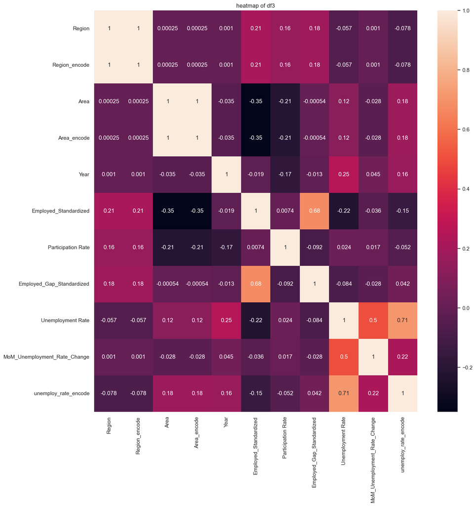

```python
df_corr = df3.corr()
plt.figure(figsize = (15 , 15))
plt.title('heatmap of df3')
sns.heatmap(df_corr , annot = True)
```

#### Classification Model Building:

- ML model to be used:
  - Random Forest will be the best model option for this data. Reasons are:-
    - Logistic Regression is primarily for binary classification and here we are classifying into 3 classes.
    - Decision tree is suitable for simple data not for complex data.

#### Therefore, Random Forest is the best model as it works well with complex data.

```python
from sklearn.linear_model import LogisticRegression
from sklearn.tree import DecisionTreeClassifier
from sklearn.ensemble import RandomForestClassifier
```

```python
def model_training(x_train, x_test, y_train, y_test, model, model_name):
    from sklearn.metrics import classification_report , accuracy_score

    model.fit(x_train, y_train)
    y_pred = model.predict(x_test)

    acc = accuracy_score(y_test  , y_pred)
    print(f"accuracy score of {model_name}: {round( acc , 3)}")

    # report = classification_report(y_test , y_pred)
    # print(report)
```

```python
from sklearn.model_selection import train_test_split
```

```python
y = df3['unemploy_rate_encode']
x = df3[['Region_encode' , 'Area_encode' ,
         # 'Month',
         'Year',
       'Employed_Standardized', 'Participation Rate',
       'Employed_Gap_Standardized' , 'MoM_Unemployment_Rate_Change',
         # 'Gap_Labour_Participation %'
        ]]
```

```python
x
```

|  | Region_encode | Area_encode | Year | Employed_Standardized | Participation Rate | Employed_Gap_Standardized | MoM_Unemployment_Rate_Change |
| --- | --- | --- | --- | --- | --- | --- | --- |
| 1 | 0 | 0 | 2019 | 0.544517 | 42.05 | 0.189923 | -0.60 |
| 2 | 0 | 0 | 2019 | 0.585683 | 43.50 | 0.261673 | 0.70 |
| 3 | 0 | 0 | 2019 | 0.610443 | 43.97 | 0.277990 | -0.43 |
| 4 | 0 | 0 | 2019 | 0.606843 | 44.68 | 0.275144 | 1.85 |
| 5 | 0 | 0 | 2019 | 0.577060 | 43.01 | 0.234843 | -1.65 |
| ... | ... | ... | ... | ... | ... | ... | ... |
| 735 | 26 | 1 | 2020 | 0.434431 | 44.09 | 1.384369 | 0.28 |
| 736 | 26 | 1 | 2020 | 0.426335 | 43.34 | 1.250363 | -0.88 |
| 737 | 26 | 1 | 2020 | 0.238862 | 41.20 | 0.392872 | 8.96 |
| 738 | 26 | 1 | 2020 | 0.231575 | 40.67 | 0.614018 | -0.41 |
| 739 | 26 | 1 | 2020 | 0.212664 | 37.57 | 0.939922 | -5.36 |

683 rows × 7 columns

```python
y.unique()
```

```
array([0, 1, 2], dtype=int64)
```

```python
x_train , x_test , y_train , y_test = train_test_split(x , y ,
                                                       test_size = 0.40,
                                                       random_state = 3)
```

```python
# LogisticRegression , DecisionTreeClassifier , RandomForestClassifier
model_training(x_train , x_test , y_train , y_test
               , model = RandomForestClassifier()
               , model_name = "Random Forest")
```

```
accuracy score of Random Forest: 0.781
```

```python
model_training(x_train , x_test , y_train , y_test
               , model = LogisticRegression()
               , model_name = "Logistic Regression")
```

```
accuracy score of Logistic Regression: 0.46
```

```python
model_training(x_train , x_test , y_train , y_test
               , model = DecisionTreeClassifier()
               , model_name = "Decision Tree")
```

```
accuracy score of Decision Tree: 0.712
```

#### ❖ We can see that the accuracy score of Random Forest is maximum. So, it is better than these two to predict that the unemployment falls under which category ('low' or 'med' or 'high') .